# Resources Matter

Converted from PDF `Norman-ResourcesFollowingDownsizing-2013-JOM.pdf` · 30 pages · anchors: page `#pN`, block `#pN-bK`

Page 1

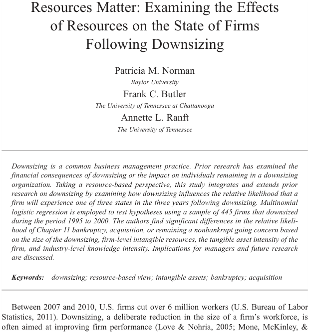

NOTE: figure/graphic rendered as an image from the PDF; its content is not machine-readable text. Caption (if any) follows as the next block.

**text found inside the figure**

Resources Matter: Examining the Effects

of Resources on the State of Firms

Following Downsizing

Patricia M. Norman

*Baylor University* Frank C. Butler

*The University of Tennessee at Chattanooga*

Annette L. Ranft

*The University of Tennessee*

*Downsizing is a common business management practice. Prior research has examined the financial consequences of downsizing or the impact on individuals remaining in a downsizing organization. Taking a resource-based perspective, this study integrates and extends prior research on downsizing by examining how downsizing influences the relative likelihood that a firm will experience one of three states in the three years following downsizing. Multinomial logistic regression is employed to test hypotheses using a sample of 445 firms that downsized during the period 1995 to 2000. The authors find significant differences in the relative likelihood of Chapter 11 bankruptcy, acquisition, or remaining a nonbankrupt going concern based on the size of the downsizing, firm-level intangible resources, the tangible asset intensity of the firm, and industry-level knowledge intensity. Implications for managers and future research are discussed.*

*Keywords:* *downsizing; resource-based view; intangible assets; bankruptcy; acquisition*

Between 2007 and 2010, U.S. firms cut over 6 million workers (U.S. Bureau of Labor Statistics, 2011). Downsizing, a deliberate reduction in the size of a firm’s workforce, is often aimed at improving firm performance (Love & Nohria, 2005; Mone, McKinley, &

2009

*Corresponding author: Annette L. Ranft, College of Business, The University of Tennessee, Knoxville, TN 37996- 4140, USA*

*E-mail: aranft@utk.edu*

Journal of Management Vol. 39 No. 7, November 2013 2009-2038

DOI: 10.1177/0149206312443560

© The Author(s) 2012 Reprints and permission: http://www. sagepub.com/journalsPermissions.nav

Page 2

2010 Journal of Management / November 2013

Barker, 1998). Frequently, downsizing is a first step toward improving financial efficiency and cost containment (Cascio, 2002; Nixon, Hitt, Lee, & Jeong, 2004) when the firm experiences difficult times (Morrow, Johnson, & Busenitz, 2004; Robbins & Pearce, 1992).

A prominent example of such efforts is Motorola’s layoff of 7,000 employees between October 2008 and early 2009. These layoffs were in addition to cutting 10,000 other positions since January 2007 (Silver, 2008, 2009) and were part of an ongoing attempt to cut costs in response to declining sales and profits in its cell phone unit. Motorola’s actions are illustrative of a prevalent business practice. Despite the practitioner emphasis on the cost reductions and efficiencies that can be achieved by downsizing, research often has found that firms experience negative performance after downsizing (Lee, 1997; Nixon et al., 2004; Worrell, Davidson, & Sharma, 1991). Firms, however, continue to turn to downsizing.

In this study of downsizing, we seek to fill two gaps in the literature. First, prior research has neglected to consider the resource profile implications of downsizing. The resource-based view has highlighted the importance of human, social, and intellectual capital as key resources for long-term viability and competitive advantage (Barney, 1991; Coff & Kryscynski, 2011; Nahapiet & Ghoshal, 1998). Therefore, empirical studies of financial results or other organizational outcomes of downsizing without considering the impact on these resources may provide only a partial understanding of the phenomenon. Second, with a few exceptions (e.g., Flanagan & O’Shaughnessy, 2005), prior empirical studies of organizational-level outcomes associated with downsizing have focused primarily on financial effects such as stock market reactions, cost reductions, and firm performance. Because downsizing can be seen as a retrenchment action, downsizing is often meant to increase the chances of a firm continuing as a going concern rather than declaring bankruptcy or being subject to a takeover by another firm (De Meuse, Bergmann, Vanderheiden, & Roraff, 2004; Robbins & Pearce, 1992). Despite this expected consequence of downsizing, no prior studies have empirically examined the organizational states reached by firms after undertaking downsizing. Our study seeks to address both of these gaps. First, we focus on organizational states by examining firms’ relative likelihood of declaring bankruptcy, being acquired, or remaining a nonbankrupt going concern three years after downsizing. Second, given the significant role that resources are likely to play in a firm’s ability to benefit from downsizing, we develop hypotheses using resource-based logic to examine the relative likelihood of these organizational states.

#### **Overview of Downsizing Literature**

Downsizing is the “intentional, permanent, and systematic reduction of an organization’s workforce” (Nixon et al., 2004: 1122). This intentional reduction in workers immediately reduces ongoing costs associated with human resources, thereby reducing operating expenses (Cascio, 2002). Therefore, downsizing has long been considered a critical part of the first stage of a retrench and turnaround strategy to strengthen a firm’s ability to remain a viable business entity (Robbins & Pearce, 1992).

Prior research has examined the financial consequences of downsizing, including market reactions (Lee, 1997; Nixon et al., 2004; Worrell et al., 1991), accounting results (Cascio, Young, & Morris, 1997; Love & Nohria, 2005), and changes in the financial expectations of

Page 3

Norman et al. / Resources and Downsizing 2011

managers (Robbins & Pearce, 1992). Findings from past research have been mixed, with studies showing positive (Chadwick, Hunter, & Walston, 2004; Wayhan & Werner, 2000), neutral (Cascio et al., 1997), and negative (Lee, 1997; Nixon et al., 2004; Worrell et al., 1991) financial results. To better explain these results, scholars have examined a variety of factors that may affect the financial success of downsizing. For example, financial outcomes improved when firms targeted their efforts more narrowly rather than making across-theboard cuts (Nixon et al., 2004) and when they had sufficient, but not too much, financial slack (Love & Nohria, 2005). Yet other studies have found that industry conditions affect the ultimate financial success of downsizing (Morrow et al., 2004).

While most studies have focused on financial outcomes, some scholars have focused on nonfinancial effects. For example, Flanagan and O’Shaughnessy (2005) examined the impact of layoffs on a firm’s reputation and found that reputation declines in firms that lay off workers. Others have theorized about the impact of downsizing on a firm’s subsequent ability to adapt and change (Freeman & Cameron, 1993; McKinley, 1993). Much of this work remains untested empirically yet predicts a period of organizational disruption during and immediately following downsizing.

In addition to firm-level outcomes, downsizing research has focused on individual-level outcomes. Individuals remaining in the firm experience attitudes and exhibit behaviors that have collectively been termed the “survivor syndrome.” Survivors have been shown to experience guilt (Brockner, Greenberg, Brockner, Bortz, Davy, & Carter, 1986), job insecurity (Brockner, Grover, O’Malley, Reed, & Glynn, 1993; Brockner, Grover, Reed, & DeWitt, 1992), reduced productivity (Zatzick & Iverson, 2006), and lower creativity (Amabile & Conti, 1999). Many of these outcomes may be somewhat mitigated by individual factors such as self-esteem and trust (Mishra & Spreitzer, 1998) and organizational factors such as procedural justice (Brockner, Konovsky, Cooper-Schneider, Folger, Martin, & Bies, 1994) or investment in practices and work design (Amabile & Conti, 1999; Mishra & Spreitzer, 1998).

In sum, research on downsizing has been conducted at the firm and individual levels. Downsizings have equivocal financial performance results and documented impacts on survivors. One explanation for these findings has been that critical resources tied to human, social, and intellectual capital may be altered or even damaged by downsizing, jeopardizing their long-term viability and competitive advantage, particularly when a firm depends on these resources to compete (Nahapiet & Ghoshal, 1998; Shaw, Duffy, Johnson, & Lockhart, 2005). Yet, the resource-based view supports the notion that a firm’s effectiveness after downsizing is influenced by the presence of resources that can be leveraged to the firm’s advantage. Our focus in this research, then, is to build from a resource-based framework to examine the organizational states associated with firms after they downsize.

We examine three specific organizational states—bankruptcy, acquisition, and remaining a nonbankrupt going concern.<sup>1</sup> The states are independent and mutually exclusive and encompass varying levels of organizational autonomy (Chancharat, Tian, Davy, McCrae, & Lodh, 2010), and all firms can be classified into the state reached in the three years following downsizing. Firms that are not acquired or that do not declare bankruptcy are classified as going concerns. Going concern firms retain status as legal and independent entities, and their managers and boards of directors have full autonomy in making strategic decisions. Firms that are acquired without declaring bankruptcy are classified as acquired. Such firms cease

Page 4

2012 Journal of Management / November 2013

to exist as legal and independent entities and are merged with another firm. Firms that enter Chapter 11 bankruptcy are classified into the final category. When firms declare Chapter 11 bankruptcy they retain their status as legal entities, but they lose some independence and autonomy in making decisions (Adler, Capkun, & Weiss, 2006). We develop arguments below to examine how the percentage of workers downsized and the types of resources possessed by the downsized firms influence the likelihood of a firm being in one of these three organizational states within three years of downsizing.

#### **Hypothesis Development**

Our hypotheses examine the likelihood that a firm will experience one of three organizational states described above following a downsizing announcement. The organizational state, we argue, is related to both the resources available to a firm as it implements the downsizing and to the expected impact that downsizing has on the firm’s ability to bundle and leverage its resources. Furthermore, because acquirers evaluate, among other factors, the resources of firms that might be taken over, we also consider how downsizing may be perceived by acquirers and, thus, affect the likelihood of acquisition versus remaining a going concern or declaring bankruptcy.

Prior literature suggests that downsizing can have three specific detrimental effects on a firm’s human and social capital. First, valuable knowledge, which is critical to a firm’s competitive advantage, is likely to be lost when a firm downsizes (Nixon et al., 2004). As employees exit, a firm’s organizational memory may be adversely affected (Scalzo, 2006; Walsh & Ungson, 1991). Exiting employees may take key knowledge and skills that are difficult for a firm to replace, especially if this knowledge is tacit and socially embedded (Ranft & Lord, 2002). Thus, downsizing can directly decrease the intellectual capital available to a firm. In addition, downsizing may lower the expectations of surviving employees, who may voluntarily leave an organization, causing further disruptions.

Second, downsizing may cause disruptions to a firm’s social networks (Shah, 2000; Shaw et al., 2005). Social networks form the basis for organizational memory and learning (Walsh & Ungson, 1991) and facilitate knowledge sharing and creation that is vital to a firm’s ability to continually innovate and change (Nahapiet & Ghoshal, 1998). Through repeated interactions, employees learn what knowledge coworkers possess, and they become adept at identifying who to seek out for certain knowledge and under what circumstances to do so (Hargadon & Sutton, 1997). Over time, trust, which facilitates knowledge sharing (Cross & Baird, 2000), develops through these interactions.

Downsizing disrupts existing relationships, both formal and informal, and reduces the sharing and transfer of knowledge within the firm (Dougherty & Bowman, 1995; Lesser & Prusak, 2001). As remaining employees take on the tasks of employees who have left, learning is likely to slow and resources may be used less efficiently (Hatch & Dyer, 2004). After downsizing, a firm’s technical knowledge and problem-solving and decision-making abilities can be significantly damaged, in part because the time required to access the information needed to make decisions and to solve problems is increased (Scalzo, 2006).

Key individuals may also be in networks that are external to the organization. When a firm’s access to external networks is broken, access to valuable knowledge may be lost

Page 5

Norman et al. / Resources and Downsizing 2013

(Hargadon & Sutton, 1997; Randel & Ranft, 2007), reducing the diversity of knowledge available to a firm and restricting the range of learning and creativity experienced by a firm. Because of the disruption in both internal and external social network ties, downsizing may reduce learning and innovation that can be generated from these social networks (Dougherty & Bowman, 1995; Fisher & White, 2000).

Third, downsizing survivors may manifest adverse reactions, including reduced productivity (Zatzick & Iverson, 2006) and creativity (Amabile & Conti, 1999) as well as work overload (Turner, Ryman, & Clark, 2007). These effects can reduce the value derived from a firm’s human capital, one of the key resources contributing to a firm’s competitive advantage (Ployhart & Moliterno, 2011). Notably, the effects on individual survivors are not independent of the network effects discussed above. Negative manifestations at the individual level are compounded when survivors interact. Furthermore, key personnel, including middle managers, are central in implementing positive changes after downsizing. However, these individuals often confront great personal uncertainty about their future and, at times, about the firm’s future, rendering them less effective as organizational change agents (O’Neill & Lenn, 1995) and less likely to exhibit effective decision making (Wiesenfeld, Brockner, & Thibault, 2000). Organizations sometimes continue to reassign survivors to new supervisors for some period after downsizing (Costanzo & Tzoumpa, 2008), making it hard for new social connections to be reinforced and exploited once they are forged.

Negative effects from work overload are also possible. If the responsibilities of survivors increase, they are able to devote less attention to each task and their abilities to carry out new tasks may be limited if the scope of their knowledge does not match their increased responsibilities (Turner et al., 2007). Further complications arise because the sharing of information tends to be reduced when employees experience work overload (Williams, 2007). These internal disruptions can spill over into customer relationships, negatively impacting customer satisfaction (Lewin, 2009).

The individual effects described are widely discussed in the downsizing literature; however, from a resource-based view, organizational advantage is driven by a set of firmspecific resources that include tangible and intangible resources. Human capital, social capital, and knowledge-based resources are important elements of a firm’s overall resource base. Therefore, we expect that states reached after downsizing will depend, in part, on a firm’s specific resources and how they are affected by downsizing.

*Size of the Downsizing*

When a greater percentage of employees is downsized, the disruptive consequences for a firm’s human and social capital are likely to be particularly acute, and this may change the knowledge and capabilities within the organization (Coff & Kryscynski, 2011; Winter, 1987), the behavior of individuals remaining (Brockner et al., 1986), and the social networks critical to firm success (Shah, 2000). The extent to which intellectual and social capital is directly lost through the departure of human capital (Nahapiet & Ghoshal, 1998; Shaw et al., 2005) increases with the size of a workforce reduction (Krishnan, Hitt, & Park, 2007). The likelihood of losing individuals who possess critical knowledge increases with the number

Page 6

2014 Journal of Management / November 2013

of people downsized. Furthermore, voluntary turnover tends to increase after downsizing, further draining a firm’s human capital (Trevor & Nyberg, 2008). More severe involuntary cuts can be expected to draw the attention of survivors and to increase the likelihood that they will consider exiting the firm.

Moreover, with a greater percentage of employees downsized, the negative reactions of survivors, as described above, are likely to be magnified (Jick, 1985). Some have theorized that cuts that are too small, while less detrimental to human and social capital, may not be sufficient to produce the desired reduction in costs. However, one recent study found that there was a significant, negative linear relationship between the size of downsizing actions and firm performance (Krishnan et al., 2007). Despite testing for a curvilinear relationship, none was found, and the authors concluded that as larger cuts are made, more valuable knowledge is lost and firm performance is negatively affected.

Even personal characteristics that help overcome some of these adverse effects become less important in moderating the negative effects of downsizing when larger percentages of employees are involved (Brockner, Grover, & Blonder, 1988). Some empirical evidence supports the notion that when large numbers of employees are dismissed, employees believe an implicit employment contract is broken by the firm (De Meuse et al., 2004). Negative survivor reactions have been shown to increase as more colleagues are dismissed (Shah, 2000). Thus, as the magnitude of downsizing increases, disruptions caused by adverse survivor responses threaten the prospects of making positive organizational changes.

In addition to the direct loss of individual knowledge and the effects on individual survivors, the use and effectiveness of internal networks may be more adversely affected with larger cuts. Some individuals provide a link between others who hold knowledge necessary to be shared and/or combined (Shah, 2000). While these individuals may not hold key intellectual property independently, they are critical nodes in a network of individuals and provide linkages and access for experts (Shah, 2000). As downsizing encompasses a greater percentage of employees, the sharing of information may be reduced and information may be shared more slowly and subject to more distortion (Turner et al., 2007). These internal disruptions can result in difficulties meeting the expectations of customers. Indeed, larger downsizing actions have been associated with lower customer satisfaction (Lewin, 2009).

With the combined effects on survivors and the potential direct loss of intellectual and social capital associated with large downsizing efforts, a firm’s ability to remain a going concern is jeopardized because potentially valuable resources are lost. The severity of large workforce reductions may damage the firm’s knowledge base and related capabilities, which are needed to implement resource utilization improvements and to reconfigure and redeploy remaining resources after a downsizing. Large downsizings may portend difficulties for a firm to remain an independent going concern, and the likelihood of bankruptcy increases.

Scholars who study acquisitions have a mixed view of how downsizing affects a firm and its attractiveness as a takeover target. Even though severe downsizing actions can be viewed as a sign that a firm is in distress, the possibility of an acquisition is not eliminated, and in fact, some scholars have noted that firms engage in downsizing to make themselves more attractive to potential buyers (Filatotchev & Toms, 2006). Reorganizing and restructuring a target firm is often the focus after an acquisition (Capron & Guilles, 2009), and as such, buyers may look more favorably at targets that have already downsized. However, potential acquirers may be

Page 7

Norman et al. / Resources and Downsizing 2015

more concerned about the possible negative effects, described above, as the percentage of employees involved in the downsizing increases. Potential acquirers, who look for proxies when determining the value of a firm’s assets (Heeley, King, & Covin, 2006), are also likely to view larger downsizing actions as an indicator that a firm’s assets are less valuable.

Reorganizing an acquired firm is one way that firms try to create value after an acquisition (Krishnan et al., 2007), but reorganizations can go beyond downsizing and restructuring to include resource transfer and recombination (Capron & Guilles, 2009). Actions such as transferring knowledge between the acquired and acquiring firm (Ranft & Lord, 2002), better leveraging existing knowledge, and creating new knowledge (Zollo & Singh, 2004) are ways new value is created in an acquisition. So, value creation opportunities exist, particularly for acquirers that expect to create value through resource recombination rather than simply increasing the efficiency of an acquired firm. Even though a firm downsizes, it may possess resources that can lead to a competitive advantage when combined with the resources of an acquirer (Bruton, Oviatt, & White, 1994; Capron, Dussuage, & Mitchell, 1998; Wernerfelt, 1984). In this case, a downsizing firm may increase its attractiveness as a takeover target by reducing its cost structure, particularly when an infusion of new management, capital, and other resources may be necessary from outside the firm to realize the benefits of these cuts (O’Neill, 1986). One means to get this infusion is to be acquired. For potential acquirers, the question of whether to acquire a downsizing firm or not rests on the efficiency achieved and resources remaining. In firms that have very large downsizing efforts, concerns over internal disruptions in human capital, social capital, and knowledgebased resources may override the potential value or resource recombination in an acquisition.

In sum, larger cuts are indicative of firm distress or mismanagement. The size of employee cuts is likely to be related to more severe disruptions among survivors and to negatively affect a firm’s social and intellectual capital. Simply cutting the number of employees, particularly in the face of the expected internal disruptions, would not be expected to lead to significant changes that will prevent a firm from entering bankruptcy. Therefore, when compared to remaining a going concern, we expect that as more employees are dismissed, the likelihood of bankruptcy will increase. When comparing how the extent of downsizing affects the likelihood of bankruptcy versus acquisition, we expect potential acquirers will view larger downsizing more negatively than more moderate cuts. More severe cuts indicate greater distress or dysfunction that will be harder to correct once a firm is acquired, and large cuts are likely to be read as signals that a firm’s resources are not as valuable as was assumed before the downsizing.

Even though we expect that more severe downsizing will generally make a firm a less attractive target, not all acquirers will be dissuaded from a takeover. As the magnitude of downsizing increases, a firm may need to make other significant changes to recover. New owners are more likely to impose the changes necessary, to leverage or combine remaining resources in the downsizing firm with their own resources, and to provide the necessary capital for these actions. Therefore, the likelihood of being acquired compared to remaining a going concern increases as more employees are dismissed. In sum, we propose the following hypotheses:

*Hypothesis 1:* The percentage of employees downsized will affect the relative likelihood of

remaining a going concern, being acquired, or declaring bankruptcy.

Page 8

2016 Journal of Management / November 2013

More specifically, the higher the percentage of employees dismissed:

*Hypothesis 1a:* The higher the likelihood of declaring bankruptcy relative to remaining a going

concern. *Hypothesis 1b:* The higher the likelihood of declaring bankruptcy relative to being acquired. *Hypothesis 1c:* The higher the likelihood of being acquired relative to remaining a going concern.

*Firm Resources*

One important way that firms create value is by bundling and deploying resources in new ways (Morrow, Sirmon, Hitt, & Holcomb, 2007). A firm’s ability to do this after downsizing will depend, in part, on the resources possessed by the firm when it downsizes. When firms possess superior resources, they tend to perform better (Crook, Ketchen, Combs, & Todd, 2008). Thus, the quality of resources possessed by firms affects their ability to create value and, ultimately, as we argue below, their organizational state.

Firms possess both tangible and intangible resources. Tangible resources are those that are physical or financial; these resources are usually accounted for on a firm’s balance sheet and include assets such as buildings, cash, and real estate (Lev, 2004; Maritan & Schnatterly, 2002). Intangible resources cannot be touched or easily quantified and are rarely accounted for on a firm’s balance sheet; examples of intangible resources are reputation, brands, and knowledge (Hall, 1992). While intangible resources are especially critical to a firm’s ability to gain a competitive advantage, firms differ based on the tangible and intangible resources they possess and those they rely on to achieve competitive advantage (Barney, 1991; Reus, Ranft, Lamont, & Adams, 2009). Thus, both tangible and intangible resources play a role in the organizational states reached by downsizing firms.

*Tangible resources.* Tangible resources are relatively transparent, are impervious to human capital disruptions, and allow ownership to be easily transferred (Miller & Shamsie, 1996). In addition, these resources can be valued and managed with little ambiguity (King, 2007). Because of the relative imperviousness of these assets to disruptions in human capital, as well as the relative ease with which they can be valued and their ownership exchanged, we expect the negative impact of disruptions from downsizing to be dampened when firms have a high level of tangible resources, or high tangible asset intensity. In these firms, downsizing should increase firm efficiency with minimal disruptions to tangible resources. The ease with which tangible assets can be valued and transferred also allows a firm to sell certain of these assets after downsizing to raise capital. For these reasons, a firm with greater tangible assets should have an increased likelihood of remaining a going concern compared to declaring bankruptcy.

When firms have high tangible asset intensity, they have made investments into their physical asset bases. Such investments include not only the acquisition of completely new tangible assets but also the upgrading of existing tangible assets. For example, firms invest in updating plants, equipment, and stores. Such investments are important for a firm’s ability to create value for customers by delivering quality products and services. The failure to make such investments in acquiring new and updating existing tangible assets is likely to

Page 9

Norman et al. / Resources and Downsizing 2017

result in negative outcomes such as low client satisfaction (Sirmon & Hitt, 2009). So, the greater a firm’s tangible asset intensity, the more likely it is to remain a going concern compared to declaring bankruptcy because it has invested in maintaining the value of its asset base.

A firm’s tangible asset intensity also affects its attractiveness as an acquisition target. Prior research has shown that being acquired becomes more likely as a firm’s tangible asset intensity increases (Ambrose & Megginson, 1992). Because tangible assets are not greatly affected by disruptions after downsizing, acquirers are often attracted to firms that possess highly valued tangible assets. The nature of tangible resources provides potential acquirers the opportunity for clear due diligence and valuation (Coff, 2002). In addition, acquiring firms can more easily and quickly integrate tangible resources after a takeover (Puranam, Singh, & Zollo, 2006; Ranft & Lord, 2002). Given that tangible assets can be valued and easily integrated, potential acquirers are likely to have fewer concerns about paying too high a premium for a firm and should be less concerned about integration. These factors should make tangible-asset-intensive firms attractive takeover targets. Thus, we suspect that greater tangible asset intensity in downsizing firms will increase the likelihood of acquisition relative to declaring bankruptcy.

The question remains, however, as to how tangible asset intensity affects the relative likelihood of being acquired compared to remaining a going concern. Even though downsizing may not have a significant effect on the value of tangible assets, downsizing, as discussed in the previous section, may be a signal that the firm is not being managed effectively. Thus, potential acquirers may be attracted to firms after they have downsized, particularly when they possess tangible assets that may be better leveraged by an acquiring firm’s management compared to the current managers. Based on the above arguments, we propose the following hypotheses:

*Hypothesis 2:* A firm’s tangible asset intensity at the time of downsizing will affect the relative

likelihood of remaining a going concern, being acquired, or declaring bankruptcy.

More specifically, the higher the firm’s tangible asset intensity at the time of the downsizing:

*Hypothesis 2a:* The lower the likelihood of declaring bankruptcy relative to remaining a going

concern. *Hypothesis 2b:* The lower the likelihood of declaring bankruptcy relative to being acquired. *Hypothesis 2c:* The higher the likelihood of being acquired relative to remaining a going concern.

*Intangible resources.* In general, firms need both tangible and intangible resources, yet intangibles are more likely to form the basis of a firm’s competitive advantage for a number of reasons. First, intangible assets cannot be easily traded because the factor market for such resources is imperfect; therefore, such resources must be developed internally (Ndofor, Sirmon, & He, 2011). Second, unlike tangible resources, which are more easily understood, the causal ambiguity associated with the creation of advantages based on intangible resources makes it difficult for others to understand how these resources are bundled and deployed together as well as exactly how a firm is leveraging these resources to arrive at a

Page 10

2018 Journal of Management / November 2013

competitive advantage (King, 2007). Third, even if a competitor understands how a firm is using intangible resources, it is difficult to duplicate them and achieve a similar result. Intangible assets are created through path-dependent processes that are firm specific (Dierickx & Cool, 1989), and their successful deployment requires that they be integrated with complementary assets and in a manner that addresses specific market contexts (Sirmon, Hitt, & Ireland, 2007).

The resource-based view has noted the importance of knowledge-based assets, including human and social capital (Nahapiet & Ghoshal, 1998). Human and social capital is subject to the disruptions described above. Layoffs can negatively affect firm reputation, another intangible resource, particularly for young and small firms (Flanagan & O’Shaughnessy, 2005). But, firms also possess a variety of other intangibles, including brands and intellectual property (e.g., patents), that are less susceptible to disruptions and that firms can continue to exploit following downsizing. It should be noted, however, that employees are central to the process of leveraging firms’ other assets, whether they are tangible or intangible.

Knowledge workers use their own know-how, an intangible asset, in combination with other knowledge and resources to solve problems and innovate within organizations (Carleton, 2011). Thus, they not only are a critical stand-alone resource but are essential in exploiting and bundling resources. While some of a firm’s knowledge workers exit because of downsizing, knowledge workers who remain are key to a firm’s ongoing activities. Interestingly, knowledge workers are more likely to exhibit characteristics found to mitigate the negative impact downsizing has on survivors. Knowledge workers tend to be more highly educated and in professional careers. Because education has been linked to greater job mobility (Decreuse & Granier, 2005), survivors may be less concerned about job loss and may manifest fewer negative responses to downsizing. Surviving knowledge workers may also have more flexibility to reconfigure social networks, lessening the negative effects of the social disruption caused by downsizing. This explanation is in line with Shah’s (2000) suggestion that survivors of downsizing are able to rapidly reconstruct the advice networks and social networks needed to perform their jobs. Furthermore, knowledge workers who exit a firm often create new links between their new employers and the firm they have left (Corredoira & Rosenkopf, 2010). These new connections assist downsized firms in tapping knowledge that can be used to create new value as resources are rebundled and redeployed (Sirmon, Gove, & Hitt, 2008).

Because of their critical nature, we expect that a firm with a greater stock of intangible assets will be better positioned to remain a going concern rather than face bankruptcy. A firm with a well-developed intangible asset base can continue to draw upon these assets after downsizing. Just as divesting businesses may be important for firms to be able to acquire and deploy new resources, downsizing may allow a firm to restructure its intangible assets in ways that will increase its competitiveness (Sirmon & Hitt, 2009).

Compared to the other states, the influence of a firm’s intangible assets on its likelihood of being acquired after downsizing is complex. While tangible assets have been recognized as a factor in attracting acquirers, the literature makes clear that intangible assets are also likely to attract buyers (Filatotchev & Toms, 2006; Heeley et al., 2006). Potential synergies are often based on integrating the intangible assets of the acquired firm with those of the acquirer (Krishnan et al., 2007). Thus, an acquiring firm is likely to consider the value of

Page 11

Norman et al. / Resources and Downsizing 2019

a firm’s intangible assets in deciding whether or not to acquire that firm. In assessing potential targets, an acquirer often looks for indicators that a firm holds valuable, intangible assets. If a target’s intangible assets are unique, a potential acquirer may have no alternative way of developing or acquiring such assets (Coff, 2002). Scholars have even suggested that some distressed firms may use downsizing as a way to make themselves more attractive targets (Filatotchev & Toms, 2006). So, potential acquirers may consider downsizing to be a step toward necessary restructuring as long as the intangible assets’ value creation potential has not been irreparably damaged. In addition, potential acquirers may believe that they will be able to more successfully leverage a firm’s assets after it is acquired and to achieve better results from these resources than the firm’s current management (Bruton et al., 1994). For these reasons, higher levels of intangible assets should increase the likelihood of an acquisition.

On the other hand, there are several conceptual arguments for why higher levels of intangible assets may reduce the likelihood of acquisition. There may be a perception that downsizing damages a firm’s ability to fully leverage its intangible assets. The potential damage to human and social capital detailed above has been well documented. Firms that acquire knowledge-intensive targets often do so to gain access to the target’s intangible resources. Under any circumstances, valuing such acquisitions is difficult because differences in the quality of intangible assets, such as knowledge, are hard to observe (Coff, 1999). After a target downsizes, potential acquirers may have even more trouble determining the value of the target’s intangibles, particularly its human and social capital.

The difficulties associated with post-acquisition integration of firms with high levels of intangible assets add further complications. Integration is often necessary to exploit a target’s intangible and human resources (Zollo & Singh, 2004). During integration, however, changes in processes and procedures create disruptions to a target’s routines (Puranam et al., 2006). Employees who hold integral knowledge may experience uncertainty about their roles or dissatisfaction with changes imposed by the acquirer and leave (Puranam et al., 2006). Remaining employees must spend time to learn new routines and adapt to different management styles, incentives, and expectations (Puranam et al., 2006; Zollo & Singh, 2004). Potential acquirers anticipate challenges with post-acquisition integration during due diligence, paying particular attention to people issues (Harding & Rouse, 2007). Given the disruptions likely to be experienced by downsizing firms, potential acquirers may be especially wary of taking over such firms and introducing further disruptions.

The conflicting expectations about how intangible resources will affect the likelihood of acquisitions after downsizing, detailed above, are drawn from the resource-based literature. Given that the theory provides no clear basis for predicting the likelihood of acquisitions, we do not make predictions about the relative likelihood of being acquired compared to each of the other two states. We do expect, however, that firms with greater intangible resources will be better positioned to stave off bankruptcy compared to remaining a going concern. Therefore, we propose:

*Hypothesis 3:* A firm’s intangible resources at the time of downsizing will affect the relative

likelihood of remaining a going concern, being acquired, or declaring bankruptcy.

Page 12

2020 Journal of Management / November 2013

More specifically, the higher the firm’s intangible resources at the time of the downsizing:

*Hypothesis 3a:* The lower the likelihood of declaring bankruptcy relative to remaining a going

concern.

#### **Methods**

Following the precedent set in prior downsizing studies, our sample is composed of firms that announced downsizing in the *Wall Street Journal* during the period 1995 to 2000 (e.g., Flanagan & O’Shaughnessy, 2005; Lee, 1997; Nixon et al., 2004; Worrell et al.*,* 1991). By conducting a search using the keywords *downsize, downsizing, workforce reduction, layoff, early retirement, attrition, voluntary buyout,* and *fire,* we found 722 announcements in 481 unique publicly held firms. We eliminated 29 firms with incomplete Compustat data. The data were then compiled to reflect a cross-sectional representation of firms that downsized during 1995 to 2000. We did this so that we did not have nonindependent observations in our sample, which would be true if we included multiple observations for a single firm. Therefore, for firms that downsized more than once in our sampling time frame, we used the most recent downsizing announcement to construct our sample. To account for these repeated actions, we control for the number of prior downsizing events. Finally, we assessed all independent and control variables to identify extreme outliers, and we removed those that were 3 standard deviations from the mean. Five firms that had downsized an extremely large percentage of their workforces and two firms that had outliers for our intangible resource measure were removed. A final sample of 445 unique firms was used in our analysis.

We collected data from Compustat for a firm’s primary Standard Industrial Classification (SIC) code, financial data, and total employees. New Generation Research’s *Bankruptcy Yearbook & Almanac* was used to identify firms that declared bankruptcy. The Security Data Corporation’s (SDC’s) database of mergers and acquisitions was used to identify firms that were acquired. Other data sources are listed below in our variable descriptions.

*Dependent Variable*

*Organizational state*. The dependent variable was a nonordinal, categorical variable with three categories. Acquisition was coded as 0, bankruptcy as 1, and going concern as 2. For each firm, the organizational state was coded by determining its status three years after the year in which the downsizing was announced. For example, if a firm announced its downsizing in 1995, we looked for any bankruptcy declaration or acquisition during the next three years, through the end of 1998.

*Independent Variables*

*Size of downsizing*. We measured the size of the downsizing event as the percentage of a firm’s total employees that were downsized (Love & Nohria, 2005; Nixon et al., 2004), as reported in the *Wall Street Journal* announcement. If a specific number of employees

Page 13

Norman et al. / Resources and Downsizing 2021

downsized was reported, the total number of employees of the firm was obtained from Compustat and a percentage was calculated.

*Tangible asset intensity*. We used capital asset intensity as a proxy for a firm’s tangible asset intensity (Anderson, Banker, & Tanakiraman, 2003). This measure was calculated as a firm’s total assets divided by firm sales in the year of the downsizing announcement. As total assets is a function of this calculation, this variable also acts as an indirect control for firm size based on total assets.

*Intangible resources*. We used market-to-book value as a proxy for a firm’s intangible resources. Intangible assets are not listed on a firm’s balance sheet in the same manner as tangible assets. Externally generated intangibles such as goodwill appear on a firm’s balance sheet, but none of a firm’s internally generated intangibles appear (Lev, 2004). Therefore, to assess the extent to which a firm relies on intangible assets, which include knowledge, brand reputation, and other assets that are not accounted for in a firm’s financial statements, researchers must rely on other sources of data. The market-to-book ratio includes the extent to which the firm’s value is attributable to intangible assets (Hall, 1992; Roberts & Dowling, 2002), and therefore, the excess of the market value of a firm’s equity compared to its book value is considered to be the value of a firm’s intangibles (Maritan & Schnatterly, 2002). We computed market and book value of the firm’s equity in the year in which the downsizing was announced.

*Control Variables*

*High tech*. A dummy variable indicates which firms operate in high-technology industries. Industries and sectors may differ in the amount of acquisition activity and the predominance of bankruptcy. For example, the particular time period of our study was marked by a surge in the number of acquisitions of high-technology firms (Sikora, 2000). We used the AeA (formerly the American Electronics Association) high-tech industry definition to classify firms according to their primary SIC code (AeANet, 2010).<sup>2</sup>

*Unit*. We controlled for whether or not the downsizing was limited to a single unit in the firm. When compared with across-the-board reductions, downsizing actions that are more targeted are thought to minimize disruptions and to indicate that management has more carefully planned the action to retain the employees who are vital to the firm’s future operations (Cascio, 2002; Nixon et al., 2004). *Unit,* a dummy variable, was coded 1 for actions limited to a single unit or area and 0 otherwise (Nixon et al., 2004).

*Year*. The year of the downsizing was included to account for possible economic fluctuations. Consistent with prior research, year was coded as the year of the downsizing event (Kang, 2008).

*Firm age*. We controlled for firm age to account for organizational life cycle effects. Younger firms suffer from a liability of newness that increases the likelihood that they will cease to exist either through bankruptcy or by takeover (Freeman, Carroll, & Hannan, 1983).

Page 14

2022 Journal of Management / November 2013

Firm age was calculated as a number of years by subtracting the year the firm was founded from the year of the downsizing announcement. Founding year was obtained from *Wards Business Directory,* Hoovers.com, and corporate websites.

*Industry knowledge intensity*. Industries differ in the extent to which they rely on knowledge (Coff, 1999; Reus et al., 2009); therefore, we controlled for industry knowledge intensity by using human asset intensity as a proxy. Human asset intensity was calculated from a combination of four indicators of workforce composition collected from the Bureau of Labor Statistics report of U.S. Census data (Coff, 2002; Ranft & Marsh, 2008). These four indicators are (1) higher levels of education, (2) higher proportion of sales people, (3) higher proportion of professionals, and (4) lower reliance on unskilled labor. The measure used here is associated with the primary three-digit SIC code of the firm.

*Acquisition*. Prior research suggests that firms often downsize after making acquisitions (Krishnan et al., 2007; O’Shaughnessy & Flanagan, 1998). To control for any differences in the ultimate state that might arise from downsizings that follow acquisitions and those that do not, we included a control indicating whether or not a firm engaged in acquisitions prior to downsizing. Acquisition is a dummy variable coded 1 if a firm made one or more acquisitions in the five years prior to the downsizing announcement and coded 0 if a firm made no acquisitions. Data for this variable was gathered from the SDC’s database of mergers and acquisitions.

*Divestiture*. Firms may change the composition of their portfolios by making divestitures (Bowman & Singh, 1993). Therefore, we also included a dummy variable to account for whether or not a firm made any divestitures in the five years prior to the downsizing announcement. This variable is coded 1 if a firm made one or more divestitures and 0 if nothing was divested. The SDC mergers and acquisitions database was the source used to code this variable.

*Prior performance*. We controlled for prior performance for three reasons. First, poorly performing firms have less slack to absorb the human and reputational costs of downsizing (Love & Nohria, 2005). Second, the market for corporate control points to the need to acquire and restructure poorly performing firms (Walsh & Kosnik, 1993) that are not using resources efficiently or are failing to deal effectively with competitive pressures. Finally, while some firms downsize after periods of poor performance, variance in prior performance is expected because firms may downsize due to institutional or other nonfinancial or sociocognitive reasons (McKinley, Zhao, & Rust, 2000) or in anticipation of future economic fluctuations (Cascio, 2002).

Our measure of prior performance is the industry-adjusted average Tobin’s *q* for the three years prior to the downsizing announcement. We used Tobin’s *q* because it is a comprehensive measure of overall corporate performance that incorporates elements of market-based and accounting-based performance and debt capacity (Perfect & Wiles, 1994). Tobin’s *q* has been used in prior research examining organizational states such as bankruptcy and going concern (e.g., Chen & Garven, 1983). In this study, we used the simple *q* ratio (Perfect & Wiles, 1994):

Page 15

Norman et al. / Resources and Downsizing 2023

where COMVAL is the year-end value of the firm’s stock, PREFVAL is the estimated yearend market value of the preferred stock, SBOND is the year-end book value of the firm’s long-term debt, STDEBT is the year-end book value of debt with a maturity of less than one year, and SRC is the firm’s year-end book value of total assets.

*Prior downsizings*. We also controlled for the number of downsizing announcements in the five-year period prior to the focal announcement. The cumulative effect of multiple layoffs may have a direct impact on the organization. Multiple layoffs also may be a result of industry norms, may indicate managers’ ability to successfully manage the process, or may indicate that a firm is in a downward spiral (McKinley et al., 2000; O’Neill, Pouder, & Buchholtz, 1998).

*Sales growth*. Low growth rates may signal decline and can affect the organizational state realized by a firm (Cameron, Kim, & Whetten, 1987). Furthermore, acquisitions are influenced by growth opportunities within firms and industries (Carow, Heron, & Saxton, 2004). We controlled for industry-adjusted sales growth by computing a compound annual growth rate for each firm over the three years prior to the downsizing announcement. We adjusted for industry by subtracting the average compound annual growth rate for all companies in the firm’s primary three-digit SIC code.

*Current ratio*. A firm’s current ratio is an indicator of the slack available to a firm (Iyer & Miller, 2008). With less slack, a firm has less flexibility to experiment and its options may be more limited than those of firms with greater slack (Davis & Stout, 1992; Iyer & Miller, 2008). In addition, because the current ratio indicates the ability of a firm to meet its obligations, lower current ratios may signify problems that increase the likelihood of bankruptcy and may decrease a firm’s ability to remain a going concern. Furthermore, greater slack may make a firm a more attractive takeover target (Davis & Stout, 1992). We controlled for each firm’s current ratio (current assets divided by current liabilities) in the year before the downsizing announcement.

*Debt-to-asset ratio*. A firm’s debt-to-asset ratio affects the ability to obtain capital (Morrow et al., 2007) and ultimately which organizational state a firm experiences after downsizing. For example, a high level of debt makes a firm less attractive as a takeover target (Novaes, 2002) and may increase the chances that it will declare bankruptcy. Therefore, we included a firm’s debt-to-asset ratio in the year of the downsizing announcement in our analysis. We calculated this ratio as total liabilities divided by total assets.

*Analysis*

Because our dependent variable is a nonordinal categorical variable, we used multinomial logistic regression to test the hypothesized relationships. This technique is appropriate when

Page 16

2024 Journal of Management / November 2013

predicting the relative likelihood of nonordered, nominal outcomes such as our dependent variable (Hoetker, 2007; Tabachnick & Fidell, 2007). Multinomial logistic regression is robust to departures from normality in predictor variables and unequal group sizes, further supporting our use of this technique (DeMaris, 1992).

#### **Results**

The standard deviations, means, and correlations for the overall sample are presented in Table 1. All of the bivariate correlations are lower than .45. These low correlations and the robustness of multinomial logistic regression toward correlated independent variables help ensure the stability of our results (Tabachnick & Fidell, 2007). In addition, we ran the variable inflation factors (VIFs) to test for possible multicollinearity. No VIF was greater than 2.4, which is below the recommended maximum of 10, further supporting that multicollinearity was not an issue (Neter, Wasserman, & Kutner, 1990). Table 2 presents the means and standard deviations for the independent and control variables within the groups representing firms that experienced each organizational state. As shown in the table, approximately 70% of firms remained a going concern, while 20% were acquired and 10% declared bankruptcy.<sup>3</sup>

The results of the multinomial logistic regression are presented in Tables 3 and 4. The overall model, shown in Table 3, is significant with a χ<sup>2</sup> of 94.13 (*p* < .001). We use the likelihood ratio tests to assess significance of individual predictor variables within the overall model.<sup>4</sup> Wald tests of significance and the odds ratios (ORs) for the pairwise group comparisons for all controls and independent variables are presented in Table 4. Significant odds ratios comparing two particular groups indicate that a particular group is more likely (OR > 1) or less likely (OR < 1) than the comparison group to have a particular characteristic. For example, industry knowledge intensity, which is significant in the overall model (χ<sup>2</sup> = 12.33, *p* < .01) in Table 3, influences the likelihood of bankruptcy relative to remaining a going concern (Wald = 10.12, *p* < .001, OR = 0.96) and acquisition (Wald = 7.05, *p* < .01, OR = 0.96). The odds ratio of 0.96 indicates that the greater the knowledge intensity of a firm’s industry, the lower the likelihood of declaring bankruptcy compared to remaining a going concern. Interpretation of these statistics is more meaningful if the inverse of the odds ratio is taken when the odds ratio is less than 1. The inverse odds ratio of 1.04 means that with a 1-point increase in industry knowledge intensity, the odds of remaining a going concern rather than declaring bankruptcy increase by 1.04 times (Bowen & Wiersema, 2004). Likewise, a 1-point increase in industry knowledge intensity increases by 1.04 times the odds that a firm will be acquired rather than declare bankruptcy. Controlling for industry knowledge intensity is important for testing hypotheses.<sup>5</sup>

Several other control variables are significant in our analysis. Year is significant, with χ<sup>2</sup> = 9.71 (*p* < .01) in the overall model shown in Table 3. Further investigating this result (Table 4), year is significantly related to the relative likelihood of acquisition versus remaining a going concern (Wald = 9.58, *p* < .001), indicating that the economic environment in any particular year affects the relative likelihood of these two outcomes. Prior performance is significant in the overall model (χ<sup>2</sup> = 9.09, *p* < .01). The analysis shows that lower prior

Page 17

2025

**Table 1**

#### **Means, Standard Deviations, and Bivariate Correlations**

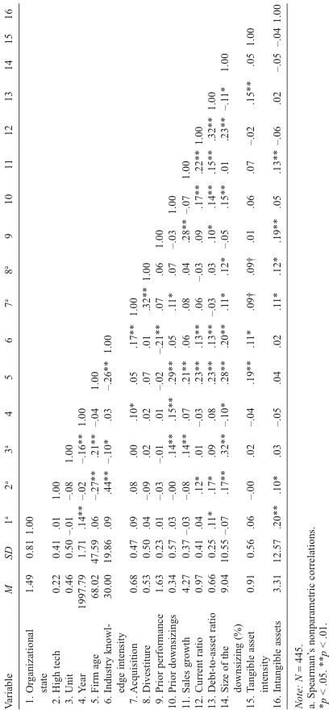

**Table 2 Means and Standard Deviations for Organizational States**

[output not shown]

**Table 3 Model Fitting and Likelihood Ratio Tests**

[output not shown]

*Note: N* = 445 †*p* < .10. **p* < .05. ***p* < .01. ****p* < .001.

performance increases the likelihood of going bankrupt after downsizing compared to remaining a going concern (Wald = 8.31, *p* < .01) and acquisition (Wald = 7.56, *p* < .01). The debt-to-asset ratio (χ<sup>2</sup>= 24.32, *p* < .001) is significant in the overall model. Firms with higher debt-to-asset ratios are more likely to declare bankruptcy compared to both remaining a going concern (Wald = 20.45, *p* < .001) and being acquired (Wald = 11.73, *p* < .001). Current ratio (χ<sup>2</sup>= 5.72, *p* < .10) is marginally significant in the overall model. Table 4 reveals that the higher a firm’s current ratio, the lower the likelihood of being acquired compared to bankruptcy (Wald = 5.21, *p* < .05) and compared to remaining a going concern (Wald = 2.69, *p* < .10).

With the controls included, as shown in Table 3, the overall model indicates support for the size of a downsizing event (χ<sup>2</sup> = 6.03, *p* < .05), tangible asset intensity (χ<sup>2</sup> = 5.58, *p* < .10), and intangible resources (χ<sup>2</sup> = 8.39, *p* < .05) as predictors of the relative likelihood of remaining a going concern, acquisition, or bankruptcy in downsizing firms. These likelihood ratio tests of our hypothesized predictors allow for further group comparisons to test our specific hypotheses.

Hypothesis 1 predicted that the percentage of employees downsized would affect the relative likelihood that a firm would remain a going concern, be acquired, or declare

**Table 4 Parameter Estimates for Organizational States**

[output not shown]

†*p* < .10. **p* < .05. ***p* < .01. ****p* < .001.

bankruptcy. This hypothesis is supported by the significant coefficient for size of downsizing (6.03, *p* < .05) in Table 3. Hypotheses 1a, 1b, and 1c predicted that when more employees are dismissed, the likelihood of bankruptcy relative to remaining a going concern or being acquired increases and the likelihood of acquisition relative to going concern increases. Comparing the significant odds ratios associated with the size of the downsizing in Table 4, we see that the likelihood of bankruptcy relative to remaining a going concern (Wald = 6.32, *p* < .05, OR = 1.04) and to being acquired (Wald = 3.90, *p* < .05, OR = 1.04) grows as a higher percentage of employees are dismissed. Thus, Hypotheses 1a and 1b are supported. A 1-point increase in the percentage of employees downsized increases the odds of bankruptcy to 1.04 times that of remaining a going concern and 1.04 times that of acquisition. However, when comparing being acquired to remaining a going concern, there is no significant difference (Wald = 0.06, *p* = *ns,* OR = 1.00). Therefore, Hypothesis 1c is not supported. Descriptive support for these relationships can be seen by examining the means of the three groups, as shown in Table 2. The mean percentage of employees downsized for bankrupt firms is 12.25%, whereas acquired and going concern firms are at 9.32% and 8.50%, respectively. Hypothesis 2, which predicted that tangible asset intensity would affect the relative likelihood that a firm experiences one of the three states after downsizing, was marginally supported, as shown in Table 3. The coefficient for tangible asset intensity (5.58) is marginally significant at *p* < .10. Hypotheses 2a and 2b predicted that the higher a firm’s tangible asset intensity, the lower the likelihood of declaring bankruptcy relative to remaining a going concern and to acquisition. The results in Table 4 provide marginal support for Hypothesis 2a (Wald = 3.51, *p* < .10, OR = 0.39) in that the lower a firm’s tangible assets, the higher the likelihood of bankruptcy compared to remaining a going concern. Hypothesis 2b (Wald = 4.44, *p* < .05, OR = 0.34) is supported. The significant odds ratio associated with tangible asset intensity when comparing bankrupt and acquired firms indicates that a 1-point increase in tangible asset intensity increases the odds of being acquired to 2.94 times that of going bankrupt. Hypothesis 2c, which predicted that the higher the tangible asset intensity of a firm, the higher the likelihood of being acquired relative to remaining a going concern, is not supported (Wald = 0.53, p = *ns,* OR = 1.18). The mean tangible asset intensity for going concern firms is 0.91, for bankrupt firms is 0.69, and for acquired firms is 1.00.

#### **Discussion**

Downsizing has been identified as a means to begin the retrenchment stage of a firm pursuing turnaround. Based on this premise and prior research that has examined both the organizational- and individual-level impacts of downsizing, we set out to examine how resource-related characteristics affect the relative likelihood of a firm remaining a going concern after downsizing, of declaring bankruptcy, or of being acquired. Taking a resourcebased perspective, we complement previous findings in the downsizing literature by providing a more complete understanding of the effects of downsizing on organizations.

Our findings suggest that a firm’s ability to use downsizing as a step toward turning around a firm and preventing future firm distress depends, in part, on its resources at the time of the downsizing. During and after downsizing, firms must continue to build, bundle, and leverage resources (Sirmon et al., 2007), and the act of downsizing necessitates changes in how a firm bundles and leverages its resources. Downsizing can contribute to the efficiency of managing a firm’s resources by eliminating unnecessary, redundant, or outdated skills; however, actions that cut too deeply can have a harmful effect because resource management requires an “adequate number of people with managerial skills” (Sirmon et al., 2007: 279). Our results, which show that firms are more likely to declare bankruptcy as a greater portion of the workforce is dismissed, suggest that when firms downsize too large a portion of their workforce, they are likely to affect the skills needed to develop new internal resources and to understand how to effectively bundle and deploy those resources.

In line with the resource-based view, we found that the greater a firm’s intangible resources, the lower the likelihood of bankruptcy compared to remaining a going concern after a firm downsizes. This suggests that a firm’s ability to create value after downsizing is enhanced when it has more intangible resources. One reason is that a firm possesses numerous types of intangible assets, including intellectual property such as patents and copyrights, brand name, and reputation that can continue to be exploited after a firm downsizes. A firm may be able to continue to exploit the value of these assets into the future regardless of the immediate disruption to human capital. For example, brand images are unlikely to be diluted immediately even if a workforce is adversely affected by downsizing. And, because intangible resources have more flexibility than tangible resources do (Sirmon et al., 2007), they may help a firm to avoid bankruptcy because it can more easily recombine and redeploy such resources.

Much of the existing downsizing literature has focused on the disruptive nature of such actions, and the downsizing literature has drawn on the interpretation that downsizing interferes with a firm’s ability to leverage its resources because of disruptions to its human and social capital. Conceptual works drawing on the resource-based view or on organizational learning perspectives have emphasized the knowledge lost as employees exit, the negative reactions of survivors, and the disruptions to existing social networks (Fisher & White, 2000; Turner et al., 2007). Empirical findings of poor firm performance and negative stock market reactions after downsizing are also often attributed to disruptions to human and social capital (Guthrie & Datta, 2008; Nixon et al., 2004).

However, our findings suggest that not all downsized firms are equally susceptible to these negative effects and that firms with certain types of resources may be able to mitigate

some of these negative effects. We are not suggesting that such negative effects do not exist. Indeed, the results of our analysis with respect to the percentage of the workforce downsized provide support for this view. Instead, we are suggesting that firm resources are vital to a firm’s ability to create value after downsizing. Our results suggest that as firms become more dependent on intangible assets, which include human capital, and as they operate in industries that depend to a greater extent upon such human capital, this increases rather than decreases their chances of remaining independent compared to the likelihood of declaring bankruptcy. It may be that highly educated and socially embedded employees have more resilience in the face of downsizing that contributes to a firm’s ability to rapidly reconfigure its social networks and help to make up for the loss of important nodes within those networks. Our findings are consistent with recent resource-based literature that notes that as firms divest some resources, they must simultaneously pay attention to other aspects of resource management to rebundle and leverage remaining assets (Sirmon et al., 2007). Morrow et al. (2007) found that the turnaround of a firm with declining performance is dependent, in part, on a firm’s resources and its ability to use those resources to create value. This echoes a statement by Cascio noting in a discussion of downsizing that it is “not possible for firms to ‘save’ or ‘shrink’ their way to prosperity” (2002: 81). Our findings provide empirical evidence that firms with assets that can be leveraged after downsizing are in a better position to avoid bankruptcy and return to prosperity. Thus, a more nuanced view of downsizing and its effects, especially with respect to the role of resources, is needed. The positive role of resource management has a rich history in the resource-based view but needs to have a greater voice in the downsizing literature.

Knowledge workers are key players in the processes firms enact to bundle resources and build capabilities (Sirmon et al., 2007). And our findings suggest that knowledge workers may indeed be more resilient and capable of ensuring that organizations effectively implement changes after downsizing. The results of a recent study of knowledge worker mobility (Corredoira & Rosenkopf, 2010) suggest why a more nuanced view of the role of knowledge workers and social networks in downsizing firms is warranted. This study found that when an employee exited a firm and went to work for another industry firm, the firm that the employee left became more likely to cite patents from the employee’s new firm. They concluded that these results occurred because ex-employees maintain social ties to their former firms and enable their former employers to gain and exploit new knowledge. More generally, the researchers concluded that knowledge workers are more concerned with social networks composed of individuals, both internal and external to their own firms, who facilitate their work; knowledge workers are less concerned with human relationships within their own firms. When firms downsize, such workers may be less susceptible to the typical survivor reactions. While Corredoira and Rosenkopf’s study did not examine downsizing specifically, it provides an explanation for our result that as downsizing firms are more dependent on intangible assets and are in more human-asset-intensive industries (i.e., a high percentage of knowledge workers), they become less likely to declare bankruptcy relative to remaining a going concern.

It should be noted that downsizing is one way that firms attempt to adjust to the environmental conditions they face. Such adjustments are necessary because as firms face different resource requirements from their environments, they must match their resource

investments to these requirements to create value (Reus et al., 2009; Sirmon & Hitt, 2009). When a mismatch exists between resource requirements from the environment and a firm’s investment in resources, value creation and performance is expected to be harmed. In such situations, firms often make adjustments to their resources, with varying degrees of success. Downsizing is one such adjustment. Our results confirm that as firms downsize and divest some of their human capital, they experience different results. Further, our results suggest that the resources available to a firm and its ability to manage these resources after downsizing contribute to firm outcomes. Future studies should more clearly examine and quantify how the match between the demands of a firm’s environment and the resources possessed by a firm affects downsizing decisions and success. For example, it would be interesting to study whether firms with greater mismatches are more likely to downsize and whether such actions are reactive or proactive. Also of interest is whether or not downsizing changes the match between the environmental requirements and firm resources. Presumably, when downsizing is taken to correct a mismatch, actions that achieve this correction should help firms to improve performance or outcomes, compared to downsizing that exacerbates or does not change the mismatch.

A firm’s tangible resources also helped to determine the state achieved after downsizing. While only marginally significant, with higher tangible asset intensity, the likelihood of bankruptcy, when compared to acquisition or to remaining a going concern, decreased. This suggests that access to a greater base of tangible assets allows a firm to leverage these after downsizing in ways that help it to avoid bankruptcy. It is important to note that our results were robust even after controlling for a number of other factors, including prior firm performance. Together, our results provide strong support for the resource-based view of the firm because when firms have valuable assets that they can leverage they are less likely to declare bankruptcy.

Two control variables, the year of the downsizing and the current ratio, impacted the likelihood of being acquired compared to remaining a going concern. In particular, the likelihood of acquisition versus remaining a going concern varied by year. This is not surprising given that the extent of acquisition activity varies based on economic and other macroenvironmental conditions (Choi & Jeon, 2011). In addition, we found that the lower a firm’s liquidity (i.e., current ratio), the less likely it will remain independent and the more likely it will be acquired. This suggests that for downsizing firms, differences in the availability of financial resources rather than in tangible or intangible resources may be driving the likelihood of being acquired versus remaining a going concern. One additional finding deserves further comment. Firms with lower liquidity were more likely to be acquired compared to entering bankruptcy. At first, this may seem counterintuitive, but it is telling to view the current ratio of acquired firms in light of the means for other measures in our study. For example, the acquired firms have the highest mean for tangible asset intensity and a significantly higher level of intangible resources than bankrupt firms do. So, it may be that acquired firms are attractive takeover targets because of their tangible and intangible assets compared to bankrupt firms, even though the bankrupt firms are relatively healthier from a liquidity standpoint alone.

Our resource measures did not help to distinguish between acquisition or remain a going concern. In part, the failure of resource characteristics to help make this distinction may be

because these two states can be viewed as more positive than the third state we studied, bankruptcy. While being acquired is sometimes viewed as a failure, in many cases being acquired is a highly desirable state. In either case, a firm is unlikely to be acquired if it does not have qualities that the acquirer believes can be exploited. These qualities vary considerably depending on the specific circumstances but often include both tangible and intangible assets such as patents, human capital, and brand name. Thus, for downsizing firms, having greater tangible asset intensity in our study increased the likelihood of achieving one of two desirable states—either remaining a going concern or being acquired—and possessing greater intangible resources increased the likelihood of remaining a going concern compared to bankruptcy. This once again confirms the importance of firm resources in determining firm states.

The resource-based literature has examined how firm resources and their management impact a variety of firm outcomes. Firm performance, stock market reactions, and other financial outcomes have been widely examined in downsizing studies. Our results suggest that additional exploration of firm resources and their management as a contingency may help to explain some of the mixed results from prior downsizing studies. Because of the important role that resources play in firm innovation, further investigation of how downsizing affects firm innovation is warranted. For example, we expect from conceptual work and case studies (e.g., Dougherty & Bowman, 1995) that downsizing may affect a firm’s innovative abilities, but innovative outcomes have not been investigated in large-scale empirical studies.

As with all studies, ours is not without limitations. Given our archival data, we were unable to determine and control for important fine-grained factors and processes that may influence organizational states in downsizing firms. For example, prior research suggests that procedural justice and how clearly intentions and rationale are communicated to employees can affect survivor reactions and performance in downsizing firms (Cascio, 2002). Primary data are required to examine these process issues—data that we were not able to collect. Thus, future research is needed to examine these relationships and their influence on different organizational states reached by downsizing firms.

In addition, as mentioned earlier, we were unable to distinguish between various types of intangible resources. It would be beneficial in future studies to create a more fine-grained method for categorizing firms’ intangible assets to investigate how different types of these resources affect the likelihood firms reach different states after downsizing. This may require surveys or a study within a particular industry. Future studies might also build on the resource-based view to examine whether the type of workers dismissed (i.e., engineers, researchers, production workers, sales personnel, clerical staff, and administrators) and the level of workers dismissed affect firm performance or other outcomes after downsizing. Similarly, future studies should consider more fine-grained measurements that would help to assess the quality of a firm’s resources, particularly its human capital and its other intangible assets. Our study showed that the overall quality of human capital at the industry level, as measured by industry knowledge intensity, decreased the likelihood of declaring bankruptcy. Is this true of firm-level measures of human capital quality? To investigate this, future studies might use the education or other professional qualifications of a firm’s workforce for such an assessment. The quality of other firm intangibles might be assessed using patent

citations, brand equity, reputation scores by outside entities, or other available measures. Survey instruments would also allow researchers to measure asset quality. Furthermore, we focused primarily on main-effect relationships in this study. Future studies could examine interaction effects as well. The interaction between the size of a downsizing and the intangible assets held by a firm may be of particular interest. Larger downsizings may have a greater negative impact when most of the assets are intangible.

Another limitation of our research lies in its cross-sectional design. As a result, we did not directly test the timing of bankruptcy or acquisition or account for those that may have occurred after the three-year post-announcement window. It is hoped, however, that our findings from this cross-sectional snapshot will encourage future research using longitudinal designs and hazard models that incorporate the timing and sequencing of organizational events. These types of designs would help explore additional relationships. For example, perhaps large layoffs are associated with more rapid bankruptcy, and repeated smaller layoffs result in the same organizational state but over a longer period of time. The potential of endogeneity is also a limitation in our study. We attempted to minimize the likelihood of endogeneity by including a three-year average of prior performance, a lagged outcome variable, and other controls that have affected the likelihood of bankruptcy or acquisition in prior studies. These approaches, while not directly testing for endogeneity, help strengthen the research design in such a way as to minimize endogeneity.

Despite these limitations, our research makes several contributions to our understanding of the impact of downsizing. Our study empirically investigates firm resources in downsizing firms and reinforces the resource-based perspective that firm-specific resources are critical determinants of firm outcomes. The availability of resources, particularly intangibles, is important because managers can leverage these resources to help a firm avoid bankruptcy. Managers in firms with high levels of intangible resources and those in knowledge-intensive industries may rely on their employees to manage through a workforce reduction, as these types of firms and industries are less susceptible to declaring bankruptcy after downsizing. Our findings also suggest that managers pursuing cost-cutting strategies, including workforce reductions, should be cognizant of the associated risks of bankruptcy. Given our findings that larger layoffs increase the likelihood of bankruptcy, the size of a particular layoff effort should be carefully considered. This finding, in conjunction with our finding that lower prior performance is also associated with an increased likelihood of bankruptcy, suggests that delaying the decision to cut workers may increase the likelihood of bankruptcy if such delays result in declining performance or the need for larger layoffs.

#### **Notes**

1. In the accounting literature, the term *going concern* is applied to nonbankrupt firms as well as to bankrupt firms that are in Chapter 11. In our study, the going concern category includes only nonbankrupt firms. For ease of discussion, we will refer to nonbankrupt going concerns simply as *going concerns* and to firms that have declared Chapter 11 as *bankrupt firms*. Note that all of the firms in our sample that declared bankruptcy filed for Chapter 11 bankruptcy.

2. The following industries are coded high tech: Computers and Office Equipment (SIC codes 3571, 3572, 2575, 3577, 2578, and 3579); Consumer Electronics (SIC codes 3651 and 3652); Communications Equipment (SIC codes 3661, 3663, and 3669); Electronic Components and Accessories (SIC codes 3671, 3672, 3675, 3676, 3677, 3678, and

3679); Semiconductors (SIC code 3674); Industrial Electronics (SIC codes 3821, 3822, 3823, 3824, 3825, 3826, and 3829); Photonics (SIC codes 3827 and 3861); Defense Electronics (SIC code 3812); Electromedical Equipment (SIC codes 3844 and 3845); Communication Services (SIC codes 4812, 4813, 4822, 4841, and 4899); Software Services (SIC codes 7371, 7372, and 7373); Data Processing and Information Services (SIC codes 7374, 7375, and 7376); and Rental, Maintenance, and Other Computer-Related Services (SIC codes 7377, 7378, and 7379).

3. Our full sample was composed of only those firms that were downsized. To help assure that our results were robust and not an artifact of the sample, we gathered data on a stratified subsample of matched pair firms that did not downsize. Our general findings held in the downsized firms but not the matched pair sets.

4. We also examined the classification table and found that our model predicts the organizational state better then chance alone (> 33.3%).

5. It should be noted that, due to the nonlinear association between the independent and dependent variables, we cannot simply multiply the odds ratio with a change in the covariate to calculate the change in the odds ratio.

#### **References**

Adler, B. E., Capkun, V., & Weiss, L. A. 2006. Theory and evidence on the bankruptcy initiation problem. *American*

*Law and Economics Association Annual Meetings,* Paper 53. Retrieved from http://law.bepress.com/cgi/viewcontent.cgi?article=1655&context=alea AeANet. 2010. *AeA’s definition of high-tech industry*. Retrieved June 10, 2010, from http://www.aeanet.org/

Publications/Idmk_definitions.asp Amabile, T. M., & Conti, R. 1999. Changes in the work environment for creativity during downsizing. *Academy of*

*Management Journal,* 42: 630-640. Ambrose, B. W., & Megginson, W. L. 1992. The role of asset structure, ownership structure, and takeover defenses

in determining acquisition likelihood. *Journal of Financial and Quantitative Analysis,* 27: 575-589. Anderson, M. C., Banker, R. D., & Tanakiraman. 2003. Are selling, general, and administrative costs “sticky”?

*Journal of Accounting Research,* 41: 47-63. Barney, J. B. 1991. Firm resources and sustained competitive advantage. *Journal of Management,* 17: 99-120. Bowen, H. P., & Wiersema, M. F. 2004. Modeling limited dependent variables: Methods and guidelines for

researchers in strategic management*.* In D. J. Ketchen & D. D. Bergh (Eds.), *Research methods in strategy and management:* 87*-*134*.* New York: Elsevier. Bowman, E. H., & Singh, H. 1993. Corporate restructuring: Reconfiguring the firm. *Strategic Management*

*Journal,* 14(special summer issue): 5-14. Brockner, J., Greenberg, J., Brockner, A., Bortz, J., Davy, J., & Carter, C. 1986. Layoffs, equity theory, and work

performance: Further evidence of the impact of survivor guilt. *Academy of Management Journal,* 29: 373-384. Brockner, J., Grover, S. L., & Blonder, M. D. 1988. Predictors of survivors’ job involvement following layoffs: A

field study. *Journal of Applied Psychology,* 3: 436-442. Brockner, J., Grover, S., O’Malley, M. N., Reed, T. F., & Glynn, M. A. 1993. Threat of future layoffs, self-esteem,

and survivor reactions: Evidence from the laboratory and the field. *Strategic Management Journal,* 14: 153-166. Brockner, J., Grover, S., Reed, T. F., & DeWitt, R. L. 1992. Layoffs, job insecurity, and survivors’ work effort:

Evidence of an inverted-U relationship. *Academy of Management Journal,* 35: 413-425. Brockner, J., Konovsky, M., Cooper-Schneider, R., Folger, R., Martin, C., & Bies, R. J. 1994. Interactive effects of

procedural justice and outcome negativity on victims and survivors of job loss. *Academy of Management Journal,* 37: 397-409. Bruton, G. D., Oviatt, B. M., & White, M. A. 1994. Performance of acquisitions of distressed firms. *Academy of*

*Management Journal,* 37: 972-989. Cameron, K. S., Kim, M. U., & Whetten, D. A. 1987. Organizational effects of decline and turbulence.

*Administrative Science Quarterly,* 32: 222-240. Capron, L., Dussuage, P., & Mitchell, W. 1998. Resource redeployment following horizontal acquisitions in Europe

and North America, 1988-1992. *Strategic Management Journal,* 19: 631-661. Capron, L., & Guilles, M. 2009. National corporate governance institutions and post-acquisition target restructur-

ing. *Strategic Management Journal,* 30: 803-833.

Carleton, K. 2011. How to motivate and retain knowledge workers in organizations: A review of the literature.

*International Journal of Management,* 28: 459-468. Carow, K., Heron, R., & Saxton, T. 2004. Do early birds get the returns? An empirical investigation of early-mover

advantages in acquisitions. *Strategic Management Journal,* 25: 563-585. Cascio, W. F. 2002. Strategies for responsible restructuring. *Academy of Management Executive,* 16: 80-91. Cascio, W. F., Young, C. E., & Morris, J. R. 1997. Financial consequences of employment-change decisions in

major U.S. corporations. *Academy of Management Journal,* 40: 1175-1189. Chadwick, C., Hunter, L. W., & Walston, S. L. 2004. Effects of downsizing practices on the performance of hospi-

tals. *Strategic Management Journal,* 25: 405-427. Chancharat, N., Tian, G., Davy, P., McCrae, M., & Lodh, S. 2010. Multiple states of financially distressed compa-

nies: Tests using a competing-risks model. *Australasian Accounting Business and Finance Journal,* 4: 27-49. Chen, K. C., & Garven, J. R. 1983. Tobin’s *q* ratio and its applications. *Illinois Business Review,* 40: 9-11. Choi, S. H., & Jeon B. N. 2011. The impact of macroeconomic environment on merger activity: Evidence from US

time-series data. *Applied Financial Economics,* 21: 233-249. Coff, R. W. 1999. How buyers cope with uncertainty when acquiring firms in knowledge-intensive industries:

Caveat emptor. *Organization Science,* 10: 144-161. Coff, R. W. 2002. Human capital, shared expertise, and the likelihood of impasse in corporate acquisitions. *Journal*

*of Management,* 28: 107-128. Coff, R. W., & Kryscynski, D. 2011. Drilling for micro-foundations of human capital-based competitive advan-

tages. *Journal of Management,* 37: 1429-1443. Corredoira, R. A., & Rosenkopf, L. 2010. Should auld acquaintance be forgot? The reverse transfer of knowledge

through mobility ties. *Strategic Management Journal,* 31: 159-181. Costanzo, L. A., & Tzoumpa, V. 2008. Enhancing organizational learning in teams: Has the middle manager got a

role? *Team Performance Management,* 14: 146-164. Crook, T. R., Ketchen, D. J., Jr., Combs, J. G., & Todd, S. Y. 2008. Strategic resources and performance: A meta-

analysis. *Strategic Management Journal,* 29: 1141-1154. Cross, R., & Baird, L. 2000. Technology is not enough: Improving performance by building organizational memory.

*Sloan Management Review,* 41: 69-78. Davis, G. R., & Stout, S. K. 1992. Organization theory and the market for corporate control: A dynamic analysis of

the characteristics of large takeover targets, 1980-1990. *Administrative Science Quarterly,* 37: 605-633. Decreuse, B., & Granier, P. 2005. Education, mobility and employers’ monopsony power: A search-theoretic analy-

sis. *Review of Labour Economics and Industrial Relations,* 19: 531-562. DeMaris, A. 1992. *Logit modeling: Practical applications.* Newbury Park, CA: Sage. De Meuse, K. P., Bergmann, T. J., Vanderheiden, P. A., & Roraff, C. E. 2004. New evidence regarding organiza-

tional downsizing and a firm’s financial performance: A long-term analysis. *Journal of Managerial Issues,* 16: 155-177. Dierickx, I., & Cool, K. 1989. Asset stock accumulation and sustainability of competitive advantage. *Management*

*Science*, *35*: 1504-1511. Dougherty, D., & Bowman, E. H. 1995. The effects of organizational downsizing on product innovation. *California*

*Management Review,* 37: 28-44. Filatotchev, I., & Toms, S. 2006. Corporate governance and financial constraints on strategic turnarounds. *Journal*

*of Management Studies,* 43: 407-433. Fisher, S. R., & White, M. A. 2000. Downsizing in a learning organization: Are there hidden costs? *Academy of*

*Management Review,* 25: 244-251. Flanagan, D. J., & O’Shaughnessy, K. C. 2005. The effects of layoffs on firm reputation. *Journal of Management,*

31: 445-463. Freeman, J., Carroll, G. R., & Hannan, T. 1983. The liability of newness: Age dependence in organizational death

rates. *American Sociological Review,* 48: 692-710. Freeman, S. J., & Cameron, K. S. 1993. Organizational downsizing: A convergence and reorientation framework.

*Organization Science,* 4: 10-29. Guthrie, J. P., & Datta, D. K. 2008. Dumb and dumber: The impact of downsizing on firm performance as moder-

ated by industry conditions. *Organization Science,* 19: 108-123.

Hall, R. 1992. The strategic analysis of intangible resources. *Strategic Management Journal,* 13: 135-144. Harding, D., & Rouse, T. 2007. Human due diligence. *Harvard Business Review, 85*(4): 124-131. Hargadon, A., & Sutton, R. I. 1997. Technology brokering and innovation in a product development firm.

*Administrative Science Quarterly,* 42: 716-749. Hatch, N. W., & Dyer, J. H. 2004. Human capital and learning as a source of sustainable competitive advantage.

*Strategic Management Journal,* 25: 1155-1178. Heeley, M. B., King, D. R., & Covin, J. G. 2006. Effects of firm R&D investment and environment on acquisition

likelihood. *Journal of Management Studies,* 43: 1513-1535. Hoetker, G. 2007. The use of logit and probit models in strategic management research: Critical issues. *Strategic*

*Management Journal,* 28: 331-343. Iyer, D. N., & Miller, K. D. 2008. Performance feedback, slack, and the timing of acquisitions. *Academy of*

*Management Journal,* 51: 808-822. Jick, T. D. 1985. As the ax falls: Budget cuts and the experience of stress in organizations. In T. A. Beehr &

R. S. Bhagat (Eds.), *Human stress in organizations:* 83-114. Newark, NJ: Wiley. Kang, E. 2008. Director interlocks and spillover effects of reputational penalties from financial reporting fraud.

*Academy of Management Journal,* 51: 537-555. King, A. W. 2007. Disentangling interfirm and intrafirm causal ambiguity: A conceptual model of causal ambiguity

and sustainable competitive advantage. *Academy of Management Review,* 32: 156-178. Krishnan, H. A., Hitt, M. A., & Park, D. 2007. Acquisition premiums, subsequent workforce reductions and post-

acquisition performance. *Journal of Management Studies,* 44: 709-732. Lee, P. M. 1997. A comparative analysis of layoff announcements and stock price reactions in the United States and

Japan. *Strategic Management Journal,* 18: 879-894. Lesser, E., & Prusak, L. 2001. Preserving knowledge in an uncertain world. *MIT Sloan Management Review,* 43:

101-102. Lev, B. 2004. Sharpening the intangibles edge. *Harvard Business Review, 82*(6): 109-116. Lewin, J. E. 2009. Business customers’ satisfaction: What happens when suppliers downsize? *Industrial Marketing*

*Management,* 38: 283-299. Love, E. G., & Nohria, N. 2005. Reducing slack: The performance consequences of downsizing by large industrial

firms, 1977-93. *Strategic Management Journal,* 26: 1087-1108. Maritan, C. A., & Schnatterly, K. 2002. Intangible capital as drivers of value: Resources, capabilities and manage-

ment systems. *Academy of Management Proceedings,* BPS S1-S6. McKinley, W. 1993. Organizational decline and adaptation: Theoretical controversies. *Organization Science,* 4: 1-9. McKinley, W., Zhao, J., & Rust, K. G. 2000. A sociocognitive interpretation of organizational downsizing. *Academy*

*of Management Review,* 25: 227-243. Miller, D., & Shamsie, J. 1996. The resource-based view of the firm in two environments: The Hollywood film

studios from 1936 to 1965. *Academy of Management Journal,* 39: 519-543. Mishra, A. K., & Spreitzer, G. M. 1998. Explaining how survivors respond to downsizing: The roles of trust,

empowerment, justice, and work redesign. *Academy of Management Review,* 23: 567-588. Mone, M. A., McKinley, W., & Barker, V. L. 1998. Organizational decline and innovation: A contingency frame-

work. *Academy of Management Review,* 23: 115-132. Morrow, J. L., Johnson, R. A., & Busenitz, L. W. 2004. The effects of cost and asset retrenchment on firm perfor-

mance: The overlooked role of a firm’s competitive environment. *Journal of Management,* 30: 189-208. Morrow, J. L., Sirmon, D. G., Hitt, M. A., & Holcomb, T. R. 2007. Creating value in the face of declining perfor-

mance: Firm strategies and organizational recovery. *Strategic Management Journal,* 28: 271-283. Nahapiet, J., & Ghoshal, S. 1998. Social capital, intellectual capital, and the organizational advantage. *Academy of*

*Management Review,* 23: 242-266. Ndofor, H. A., Sirmon, D. G., & He, X. 2011. Firm resources, competitive actions and performance: Investigating

a mediated model with evidence from the in-vitro diagnostics industry. *Strategic Management Journal,* 32: 640-657. Neter, J., Wasserman, W., & Kutner, M. H. 1990. *Applied linear statistical models* (3rd ed.). Homewood, IL: Irwin. Nixon, R. D., Hitt, M. A., Lee, H., & Jeong, E. 2004. Market reactions to announcements of corporate downsizing

actions and implementation strategies. *Strategic Management Journal,* 25: 1121-1129.

Novaes, W. 2002. Managerial turnover and leverage under a takeover threat. *Journal of Finance,* 57**:** 2619-

2650. O’Neill, H. M. 1986. Turnaround and recovery: What strategy do you need? *Long Range Planning,* 19: 80-89. O’Neill, H. M., & Lenn, D. J. 1995. Voices of survivors: Words that downsizing CEOs should hear. *Academy of*

*Management Executive,* 9: 23-33. O’Neill, H. M., Pouder, R. W., & Buchholtz, A. K. 1998. Patterns in the diffusion of strategies across organizations:

Insights from the innovation diffusion literature. *Academy of Management Review,* 23: 98-105. O’Shaughnessy, K. C., & Flanagan, D. J. 1998. Determinants of layoff announcements following M&As: An

empirical investigation. *Strategic Management Journal,* 19: 989-999. Perfect, S. B., & Wiles, K. W. 1994. Alternative constructions of Tobin’s *q:* An empirical comparison. *Journal of*

*Empirical Finance,* 1: 313-341. Ployhart, R. E., & Moliterno, T. P. 2011. Emergence of the human capital resource: A multilevel model. *Academy*

*of Management Review,* 36: 127-150. Puranam, P., Singh, H., & Zollo, M. 2006. Organizing for innovation: Managing the coordination–autonomy

dilemma in technology acquisitions. *Academy of Management Journal,* 49: 263-280. Randel, A., & Ranft, A. L. 2007. Motivations to maintain social ties with coworkers: The moderating role of turn-

over intentions. *Group and Organization Management,* 32: 208-232. Ranft, A. L., & Lord, M. D. 2002. Acquiring new technologies and capabilities: A grounded model of acquisition

implementation. *Organization Science,* 13: 420-441. Ranft, A. L., & Marsh, S. 2008. Accessing knowledge through alliances and acquisitions: An empirical examination

of new market entry. *Journal of Managerial Issues,* 20: 51-67. Reus, T. H., Ranft, A. L., Lamont, B. T., & Adams, G. L. 2009. An interpretive systems view of knowledge invest-

ments. *Academy of Management Review,* 34: 382-400. Robbins, D. K., & Pearce, J. A. 1992. Turnaround: Retrenchment and recovery. *Strategic Management Journal,* 13:

287-309. Roberts, P. W., & Dowling, G. R. 2002. Corporate reputation and sustained superior financial performance.

*Strategic Management Journal,* 23: 1077-1093. Scalzo, N. J. 2006. Memory loss? Corporate knowledge and radical change. *Journal of Business Strategy,* 27:

60-69. Shah, P. P. 2000. Network destruction: The structural implications of downsizing. *Academy of Management*

*Journal,* 43: 101-112. Shaw, J., Duffy, M. K., Johnson, J. L., & Lockhart, D. E. 2005. Turnover, social capital losses, and performance.

*Academy of Management Journal,* 48: 594-606. Sikora, M. 2000. M&A almanac: 1999 M&A profile. *Mergers and Acquisitions,* 35(February): 25. Silver, S. 2008. Motorola speed dials cell overhaul. *Wall Street Journal,* October 29: B1. Silver, S. 2009. Corporate news: Motorola cutbacks affect high-end devices. *Wall Street Journal,* February 2: B3. Sirmon, D. G., Gove, S., & Hitt, M. A. 2008. Resource management in dyadic competitive rivalry: The effects of

resource bundling and deployment. *Academy of Management Journal,* 5: 919-935. Sirmon, D. G., & Hitt, M. A. 2009. Contingencies with dynamic managerial capabilities: Interdependent effects of

resource investment and deployment on firm performance. *Strategic Management Journal,* 30: 1375-1394. Sirmon, D. G., Hitt, M. A., & Ireland, R. D. 2007. Managing firm resources in dynamic environments to create

value: Looking inside the black box. *Academy of Management Review,* 32: 273-292. Tabachnick, B. G., & Fidell, L. S. 2007. *Using multivariate statistics* (5th ed.). Boston: Pearson/Allyn and Bacon. Trevor, C. O., & Nyberg, A. J. 2008. Keeping your headcount when all about you are losing theirs: Downsizing,

voluntary turnover rates, and the moderating role of HR practices. *Academy of Management Journal,* 51: 259-276. Turner, C. A., Ryman, J. A., & Clark, W. A. 2007. The anorexic trend of business: A resource-based view of mana-

gerially downsized firms. *Journal of Global Business Issue,* 1: 81-87. U.S. Bureau of Labor Statistics. 2011. *Extended mass layoffs—Fourth quarter 2010: Annual totals—2010*.

Retrieved from http://www.bls.gov/news.release/archives/mslo_02112011.pdf Walsh, J. P., & Kosnik, R. D. 1993. Corporate raiders and their disciplinary role in the market. *Academy of*

*Management Journal,* 36: 671-702.

Walsh, J. P., & Ungson, G. R. 1991. Organizational memory. *Academy of Management Review,* 16: 57-91. Wayhan, V. B., & Werner, S. 2000. The impact of workforce reductions on financial performance: A longitudinal

perspective. *Journal of Management,* 26: 341-363. Wernerfelt, B. 1984. A resource-based view of the firm. *Strategic Management Journal,* 5: 171-180. Wiesenfeld, B. M., Brockner, J., & Thibault, V. 2000. Procedural fairness, managers’ self-esteem and managerial

behaviors following a layoff. *Organizational Behavior and Human Decision Process,* 83: 1-32. Williams, M. 2007. Building genuine trust through interpersonal emotion management: A threat regulation model

of collaboration across boundaries. *Academy of Management Review,* 32: 595-621. Winter, S. G. 1987. Knowledge and competence as strategic assets. In D. Teece (Ed.), *The competitive challenge*:

159-183. Cambridge, MA: Ballinger. Worrell, D. L., Davidson, W. N., & Sharma, V. M. 1991. Layoff announcements and stockholder wealth. *Academy*

*of Management Journal,* 34: 662-678. Zatzick, C. D., & Iverson, R. D. 2006. High-involvement management and workforce reduction: Competitive

advantage or disadvantage? *Academy of Management Journal,* 49: 999-1015. Zollo, M., & Singh, H. 2004. Deliberate learning in corporate acquisitions: Post-acquisition strategies and integra-

tion capability in U.S. bank mergers. *Strategic Management Journal,* 25: 1233-1256.